# Quiz 2

cwl

6/1/2021

### 1.

Load the cell segmentation data from the AppliedPredictiveModeling package using the commands:

```r
library(AppliedPredictiveModeling)
data(segmentationOriginal)
library(caret)
```

1. Subset the data to a training set and testing set based on the Case variable in the data set.
2. Set the seed to 125 and fit a CART model with the rpart method using all predictor variables and default caret settings.
3. In the final model what would be the final model prediction for cases with the following variable values:
1. TotalIntench2 = 23,000; FiberWidthCh1 = 10; PerimStatusCh1=2
2. TotalIntench2 = 50,000; FiberWidthCh1 = 10;VarIntenCh4 = 100
3. TotalIntench2 = 57,000; FiberWidthCh1 = 8;VarIntenCh4 = 100
4. FiberWidthCh1 = 8;VarIntenCh4 = 100; PerimStatusCh1=2

```r
inTrain <- createDataPartition(y = segmentationOriginal$Case, p = 0.6, list = FALSE)
training <- segmentationOriginal[inTrain,] # split dataset
testing <- segmentationOriginal[-inTrain,]
head(segmentationOriginal)
```

```
##        Cell  Case Class   AngleCh1 AngleStatusCh1 AreaCh1 AreaStatusCh1
## 1 207827637  Test    PS 143.247705              1     185             0
## 2 207932307 Train    PS 133.752037              0     819             1
## 3 207932463 Train    WS 106.646387              0     431             0
## 4 207932470 Train    PS  69.150325              0     298             0
## 5 207932455  Test    PS   2.887837              2     285             0
## 6 207827656  Test    WS  40.748298              2     172             0
##   AvgIntenCh1 AvgIntenCh2 AvgIntenCh3 AvgIntenCh4 AvgIntenStatusCh1
## 1    15.71186    3.954802    9.548023    2.214689                 0
## 2    31.92327  205.878517   69.916880  164.153453                 0
## 3    28.03883  115.315534   63.941748  106.696602                 0
## 4    19.45614  101.294737   28.217544   31.028070                 0
## 5    24.27574  111.415441   20.474265   40.577206                 0
## 6   325.93333  652.606061  128.690909  346.854545                 1
##   AvgIntenStatusCh2 AvgIntenStatusCh3 AvgIntenStatusCh4 ConvexHullAreaRatioCh1
```

[output cut: 209 more lines]

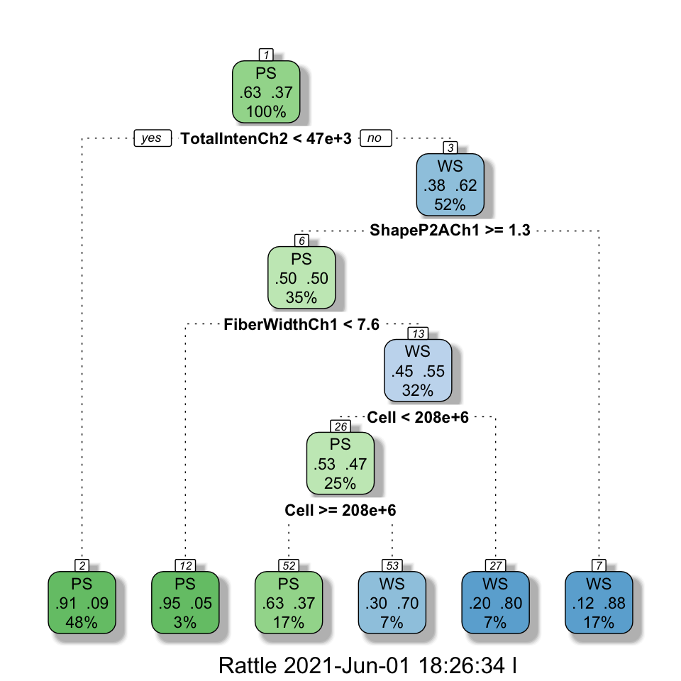

```r
set.seed(125)
modFit <- train(Class ~ .,method="rpart",data=training)

library(rattle)
fancyRpartPlot(modFit$finalModel)
```

### 2

Load the olive oil data using the commands:

```r
library(pgmm)
data(olive)
olive = olive[,-1]
```

These data contain information on 572 different Italian olive oils from multiple regions in Italy. Fit a classification tree where Area is the outcome variable. Then predict the value of area for the following data frame using the tree command with all defaults

newdata = as.data.frame(t(colMeans(olive)))

What is the resulting prediction? Is the resulting prediction strange? Why or why not?

```r
library(caret)
library(pgmm)
data(olive)
olive = olive[,-1]

head(olive)
```

```
##   Area Palmitic Palmitoleic Stearic Oleic Linoleic Linolenic Arachidic
## 1    1     1075          75     226  7823      672        36        60
## 2    1     1088          73     224  7709      781        31        61
## 3    1      911          54     246  8113      549        31        63
## 4    1      966          57     240  7952      619        50        78
## 5    1     1051          67     259  7771      672        50        80
## 6    1      911          49     268  7924      678        51        70
##   Eicosenoic
## 1         29
## 2         29
## 3         29
## 4         35
## 5         46
## 6         44
```

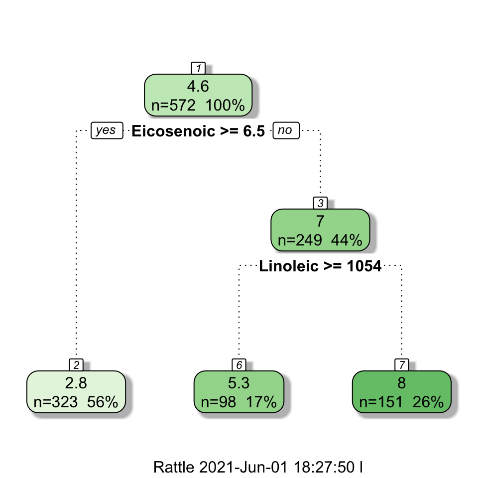

```r
modFit <- train(Area ~ .,method="rpart",data=olive)

library(rattle)
fancyRpartPlot(modFit$finalModel)
```

```r
newdata = as.data.frame(t(colMeans(olive)))
predict(modFit, newdata = newdata)
```

```
##        1
## 2.783282
```